# Black Rock Stock Price Analysis of Past 10y

## Team members:

- Janna Freund (ETU20250782)
- Tetiana Fedotova (ETU20250781)
- Mridul Jain (ETU20250784)
- Kezia Christy Wibowo (ETU20240232)

#### Github Repository:https://github.com/MridulJain1101/Black-Rock-Stock-Price-Prediction-using-Historical-Data-of-Past-10-Years

## Step 1: Load the important packages and call libraries

```r
#install.packages("quantmod")
```

```r
library(quantmod)
library(lubridate)
library(dplyr)
library(forecast)
library(Metrics)
```

```r
library(ggplot2)
library(TTR)
library(urca)
library(lmtest)
```

## Step 2: Load the Black Rock historical data

```r
# Define the start date (10 years ago from 2026-02-28)
start_date = as.Date("2016-03-01")
end_date = as.Date("2026-02-28")

# Fetch the data from Yahoo Finance
options(download.file.method = "libcurl")
getSymbols("BLK", src = "yahoo", from = start_date, to = end_date)
```

```
## [1] "BLK"
```

```r
# View the first few rows
head(BLK)
```

```
##            BLK.Open BLK.High BLK.Low BLK.Close BLK.Volume BLK.Adjusted
## 2016-03-01   315.27   323.03  314.13    322.57     832300     250.0627
## 2016-03-02   320.10   327.23  318.40    326.73    1051400     253.2876
## 2016-03-03   323.46   324.97  320.43    323.14     837700     252.2726
## 2016-03-04   323.28   325.87  320.70    323.76     671700     252.7566
## 2016-03-07   320.52   327.86  317.83    326.73     682400     255.0753
## 2016-03-08   323.30   325.00  316.75    320.40     674500     250.1336
```

```r
tail(BLK)
```

```
##            BLK.Open BLK.High BLK.Low BLK.Close BLK.Volume BLK.Adjusted
## 2026-02-20  1074.91  1102.58 1068.07   1093.64     567700     1087.585
## 2026-02-23  1099.97  1108.22 1056.00   1071.01     727200     1065.081
## 2026-02-24  1061.13  1093.86 1051.41   1081.05     737300     1075.065
## 2026-02-25  1086.49  1097.67 1061.50   1093.78     774200     1087.725
## 2026-02-26  1100.00  1108.05 1060.12   1090.27     725400     1084.234
## 2026-02-27  1073.07  1080.00 1040.45   1063.23    1191600     1057.344
```

## Step 3: Naming the target column

```r
blk_adj_close = Ad(BLK)
blk_adj_close
```

```
##            BLK.Adjusted
## 2016-03-01     250.0627
## 2016-03-02     253.2876
## 2016-03-03     252.2726
## 2016-03-04     252.7566
## 2016-03-07     255.0753
## 2016-03-08     250.1336
## 2016-03-09     256.3087
## 2016-03-10     253.7169
## 2016-03-11     265.1618
## 2016-03-14     263.7332
##        ...
## 2026-02-13    1065.5779
## 2026-02-17    1066.7314
## 2026-02-18    1086.2130
## 2026-02-19    1075.2938
## 2026-02-20    1087.5853
## 2026-02-23    1065.0806
## 2026-02-24    1075.0651
## 2026-02-25    1087.7246
## 2026-02-26    1084.2340
## 2026-02-27    1057.3436
```

## Step 4: Checking missing values

```r
colSums(is.na(BLK))
```

```
##     BLK.Open     BLK.High      BLK.Low    BLK.Close   BLK.Volume BLK.Adjusted
##            0            0            0            0            0            0
```

## Step 5: Creating a data frame out of the current xts object and renaming the columns

```r
blk_clean = as.data.frame(BLK)
blk_clean$Date = as.Date(rownames(blk_clean))
rownames(blk_clean) = NULL

colnames(blk_clean) = c("Open", "High", "Low", "Close", "Volume", "Adj.Close", "Date")
```

## Step 6: Data transformation to monthly ts

```r
blk_monthly = blk_clean %>%
  mutate(YearMonth = floor_date(Date, "month")) %>%
  group_by(YearMonth) %>%
  summarise(Adj.Close = mean(Adj.Close), .groups = "drop")
blk_ts = ts(blk_monthly$Adj.Close,
             start     = c(2016, 3),
             frequency = 12)
class(blk_ts)
```

```
## [1] "ts"
```

- Metric Selection: The Adjusted Close price was selected as the target variable for this 10-year longitudinal analysis because it accurately reflects the asset’s true value after accounting for corporate actions, such as dividend payouts and stock splits.
- Aggregation: The data was aggregated from a daily to a monthly frequency to reduce microscopic market noise and high-frequency volatility, thereby enhancing the stability and reliability of the time series forecasting models.

## Step 7: Visual inspection to check trend and seasonality

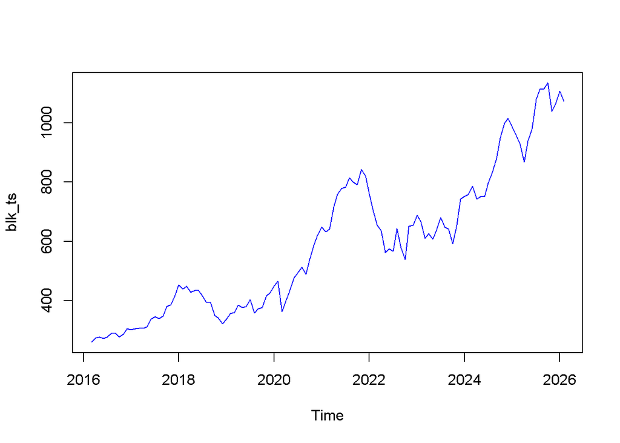

```r
plot(blk_ts, type = "l", col = "blue")
```

- Visual Diagnostics: Initial visual inspection of the time series reveals a pronounced deterministic upward trend over the 10-year period.
- Next step is to plot for first 3 years to check seasonality

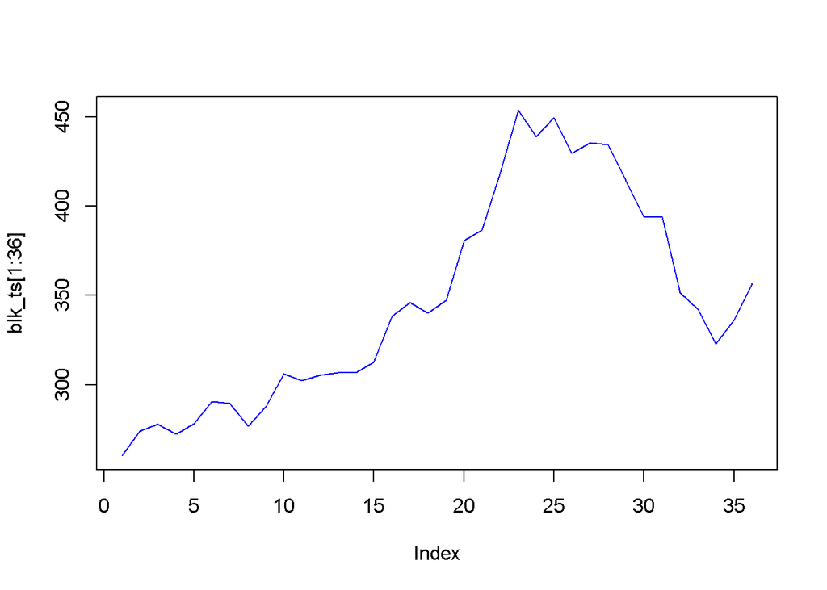

```r
plot(blk_ts[1:36], type = "l", col = "blue")
```

- Seasonality Check: By isolating the first 36 months of data (3 years), we observe no strict, recurring seasonal patterns. Consequently, while Simple Exponential Smoothing (SES) may underperform due to the trend, Holt’s Linear Trend method and Autoregressive Integrated Moving Average (ARIMA) models represent theoretically sound approaches for this dataset.

## Step 8: Splitting the data set into train and test data

```r
n = nrow(blk_ts)
train_blk = window (blk_ts, end = c(2024,2))
test_blk = window (blk_ts, start = c(2024,3))
h = length (test_blk) #no of forecasts we need to generate
```

## Step 9: Moving Average Model with 3,6 and 12 months forecast

```r
ma3_blk  = SMA(train_blk, n = 3)
ma6_blk  = SMA(train_blk, n = 6)
ma12_blk = SMA(train_blk, n = 12)

pred_ma3_blk  = ts(rep(tail(na.omit(ma3_blk),  1), h), start = start(test_blk), frequency = 12)
pred_ma6_blk  = ts(rep(tail(na.omit(ma6_blk),  1), h), start = start(test_blk), frequency = 12)
pred_ma12_blk = ts(rep(tail(na.omit(ma12_blk), 1), h), start = start(test_blk), frequency = 12)

mape_ma3_blk  = mape(test_blk, pred_ma3_blk)
mape_ma6_blk  = mape(test_blk, pred_ma6_blk)
mape_ma12_blk = mape(test_blk, pred_ma12_blk)

mape_ma3_blk
```

```
## [1] 0.1985694
```

```r
mape_ma6_blk
```

```
## [1] 0.2624537
```

```r
mape_ma12_blk
```

```
## [1] 0.2916274
```

## Step 10: Exponential smoothing

- Model Assumptions and Hypotheses:In applying exponential smoothing techniques, we construct competing hypotheses regarding the underlying structural components of the Black Rock stock price:
  - $H_0$: The time series contains only a fundamental level with random noise, exhibiting no significant trend or seasonal components (Simple Exponential Smoothing is optimal).
  - $H_A$: The time series possesses a definitive structural trend and/or seasonal variation (Holt’s Linear or Holt-Winters models will yield significantly lower forecast errors).

  ```r
  #SES
  pred_ses_blk = ses(train_blk, h = h)
  mape_ses_blk = mape(test_blk, pred_ses_blk$mean)
  mape_ses_blk
  ```

  ```
  ## [1] 0.1933931
  ```

  ```r
  summary(pred_ses_blk)
  ```

  ```
  ##
  ## Forecast method: Simple exponential smoothing
  ##
  ## Model Information:
  ## Simple exponential smoothing
  ##
  ## Call:
  ## ses(y = train_blk, h = h)
  ##
  ##   Smoothing parameters:
  ##     alpha = 0.9999
  ##
  ##   Initial states:
  ##     l = 260.3298
  ##
  ##   sigma:  34.7736
  ##
  ##      AIC     AICc      BIC
  ## 1123.537 1123.798 1131.230
  ##
  ## Error measures:
  ##                    ME     RMSE      MAE       MPE    MAPE      MASE       ACF1
  ## Training set 5.192633 34.40949 25.46663 0.9037788 4.94636 0.2224455 0.06941428
  ##
  ## Forecasts:
  ##          Point Forecast    Lo 80    Hi 80    Lo 95     Hi 95
  ## Mar 2024       758.7727 714.2085 803.3369 690.6177  826.9278
  ## Apr 2024       758.7727 695.7526 821.7928 662.3918  855.1537
  ## May 2024       758.7727 681.5904 835.9550 640.7326  876.8128
  ## Jun 2024       758.7727 669.6510 847.8944 622.4729  895.0726
  ## Jul 2024       758.7727 659.1321 858.4133 606.3856  911.1598
  ## Aug 2024       758.7727 649.6223 867.9231 591.8416  925.7039
  ## Sep 2024       758.7727 640.8771 876.6684 578.4669  939.0785
  ## Oct 2024       758.7727 632.7372 884.8082 566.0180  951.5274
  ## Nov 2024       758.7727 625.0921 892.4534 554.3258  963.2196
  ## Dec 2024       758.7727 617.8611 899.6844 543.2670  974.2785
  ## Jan 2025       758.7727 610.9835 906.5620 532.7486  984.7968
  ## Feb 2025       758.7727 604.4120 913.1334 522.6984  994.8470
  ## Mar 2025       758.7727 598.1091 919.4363 513.0589 1004.4865
  ## Apr 2025       758.7727 592.0443 925.5011 503.7836 1013.7618
  ## May 2025       758.7727 586.1925 931.3529 494.8340 1022.7114
  ## Jun 2025       758.7727 580.5327 937.0127 486.1781 1031.3673
  ## Jul 2025       758.7727 575.0472 942.4983 477.7888 1039.7567
  ## Aug 2025       758.7727 569.7208 947.8247 469.6427 1047.9027
  ## Sep 2025       758.7727 564.5404 953.0051 461.7199 1055.8255
  ## Oct 2025       758.7727 559.4946 958.0509 454.0031 1063.5423
  ## Nov 2025       758.7727 554.5734 962.9720 446.4769 1071.0686
  ## Dec 2025       758.7727 549.7681 967.7773 439.1278 1078.4177
  ## Jan 2026       758.7727 545.0708 972.4746 431.9439 1085.6015
  ## Feb 2026       758.7727 540.4746 977.0708 424.9146 1092.6308
  ```

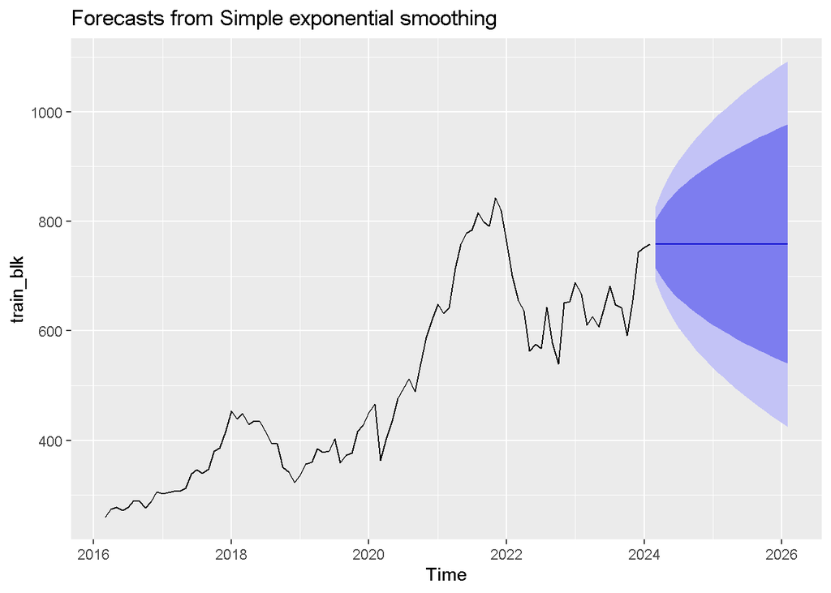

  ```r
  autoplot(pred_ses_blk) +
    ylim(min(train_blk), max(pred_ses_blk$upper))
  ```

```r
#HOLT
pred_holt_blk = holt(train_blk, h = h)
mape_holt_blk = mape(test_blk, pred_holt_blk$mean)
mape_holt_blk
```

```
## [1] 0.1398866
```

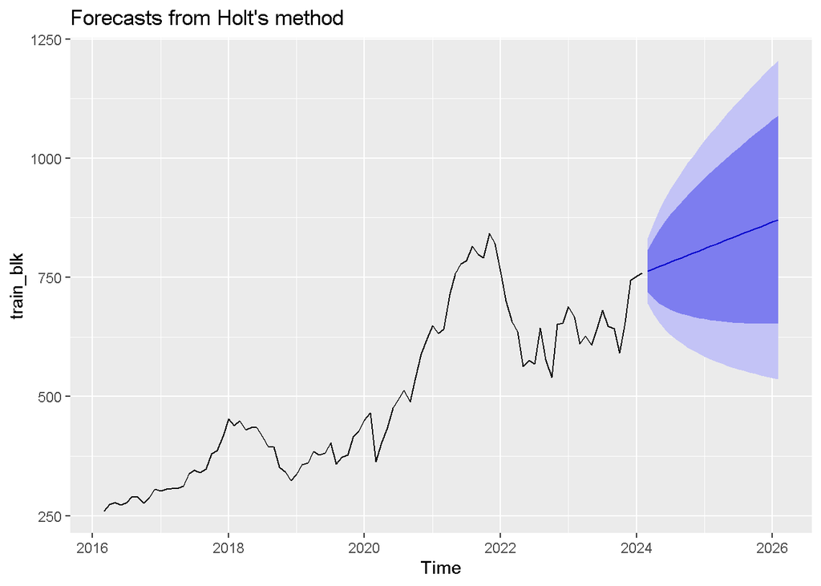

```r
autoplot(pred_holt_blk) +
  ylim(min(train_blk), max(pred_holt_blk$upper))
```

```r
#Add Holt
pred_add_blk = hw(train_blk, h = h, frequency = 12, seasonal = "additive")
mape_add_blk = mape(test_blk, pred_add_blk$mean)
mape_add_blk
```

```
## [1] 0.1279039
```

```r
summary(pred_add_blk)
```

```
##
## Forecast method: Holt-Winters' additive method
##
## Model Information:
## Holt-Winters' additive method
##
## Call:
## hw(y = train_blk, h = h, seasonal = "additive", frequency = 12)
##
##   Smoothing parameters:
##     alpha = 0.9998
##     beta  = 1e-04
##     gamma = 1e-04
##
##   Initial states:
##     l = 245.7261
##     b = 6.1731
##     s = 9.1309 24.426 18.2772 14.978 -17.9585 -11.8119
##            2.0451 4.1599 0.9288 -14.3012 -8.6625 -21.2116
##
##   sigma:  33.2005
##
##      AIC     AICc      BIC
## 1127.167 1135.013 1170.761
##
## Error measures:
##                      ME     RMSE      MAE        MPE     MAPE      MASE
## Training set -0.9197508 30.30778 23.43506 -0.3991029 4.909849 0.2047002
##                    ACF1
## Training set 0.06385717
##
## Forecasts:
##          Point Forecast    Lo 80     Hi 80    Lo 95     Hi 95
## Mar 2024       734.5963 692.0481  777.1445 669.5245  799.6681
## Apr 2024       753.3041 693.1342  813.4741 661.2822  845.3261
## May 2024       753.8311 680.1367  827.5255 641.1253  866.5369
## Jun 2024       775.2220 690.1240  860.3200 645.0758  905.3681
## Jul 2024       784.6214 689.4749  879.7678 639.1074  930.1353
## Aug 2024       788.6716 684.4392  892.9039 629.2619  948.0812
## Sep 2024       780.9750 668.3859  893.5640 608.7848  953.1651
## Oct 2024       780.9885 660.6200  901.3570 596.9008  965.0763
## Nov 2024       820.0978 692.4216  947.7741 624.8339 1015.3618
## Dec 2024       829.5684 694.9792  964.1576 623.7321 1035.4048
## Jan 2025       841.8711 700.7058  983.0363 625.9775 1057.7647
## Feb 2025       832.7426 685.2931  980.1922 607.2380 1058.2473
## Mar 2025       808.5665 655.0871  962.0459 573.8400 1043.2930
## Apr 2025       827.2743 667.9934  986.5552 583.6751 1070.8735
## May 2025       827.8013 662.9217  992.6808 575.6397 1079.9628
## Jun 2025       849.1921 678.8968 1019.4875 588.7479 1109.6364
## Jul 2025       858.5915 683.0464 1034.1366 590.1184 1127.0646
## Aug 2025       862.6417 681.9983 1043.2851 586.3714 1138.9120
## Sep 2025       854.9451 669.3424 1040.5479 571.0903 1138.8000
## Oct 2025       854.9587 664.5248 1045.3926 563.7152 1146.2022
## Nov 2025       894.0680 698.9216 1089.2144 595.6173 1192.5187
## Dec 2025       903.5386 703.7898 1103.2873 598.0492 1209.0279
## Jan 2026       915.8412 711.5929 1120.0895 603.4704 1228.2120
## Feb 2026       906.7128 698.0611 1115.3645 587.6075 1225.8180
```

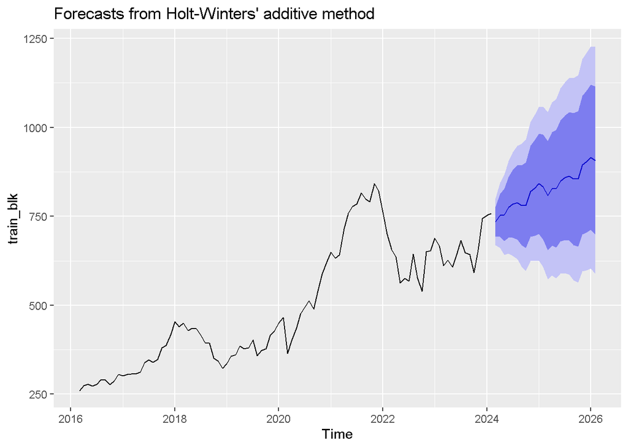

```r
autoplot(pred_add_blk) +
  ylim(min(train_blk), max(pred_add_blk$upper))
```

```r
#Mult Holt
pred_mult_blk = hw(train_blk, h = h, frequency = 12, seasonal = "multiplicative")
mape_mult_blk = mape(test_blk, pred_mult_blk$mean)
mape_mult_blk
```

```
## [1] 0.09218514
```

```r
summary(pred_mult_blk)
```

```
##
## Forecast method: Holt-Winters' multiplicative method
##
## Model Information:
## Holt-Winters' multiplicative method
##
## Call:
## hw(y = train_blk, h = h, seasonal = "multiplicative", frequency = 12)
##
##   Smoothing parameters:
##     alpha = 0.7275
##     beta  = 0.149
##     gamma = 0.1227
##
##   Initial states:
##     l = 241.4468
##     b = 6.9693
##     s = 1.0181 1.06 1.094 1.0822 0.9446 0.937
##            1.0059 0.9739 0.9887 0.972 0.9835 0.9399
##
##   sigma:  0.0773
##
##      AIC     AICc      BIC
## 1145.227 1153.073 1188.821
##
## Error measures:
##                      ME    RMSE     MAE         MPE    MAPE      MASE      ACF1
## Training set 0.06477914 34.1926 26.6175 -0.01603173 5.55752 0.2324982 0.2159176
##
## Forecasts:
##          Point Forecast       Lo 80     Hi 80       Lo 95     Hi 95
## Mar 2024       710.6989  640.304366  781.0934  603.039755  818.3580
## Apr 2024       736.3103  639.843413  832.7772  588.776912  883.8437
## May 2024       731.9855  611.780233  852.1907  548.147435  915.8235
## Jun 2024       760.3864  609.258179  911.5146  529.255728  991.5171
## Jul 2024       766.5046  586.686668  946.3225  491.496810 1041.5124
## Aug 2024       774.9208  564.381013  985.4607  452.927957 1096.9137
## Sep 2024       751.3730  518.460992  984.2851  395.164797 1107.5813
## Oct 2024       748.1906  486.769299 1009.6118  348.381245 1147.9999
## Nov 2024       847.0120  516.756412 1177.2676  341.929652 1352.0944
## Dec 2024       893.4228  507.963090 1278.8825  303.913050 1482.9325
## Jan 2025       912.3707  479.934024 1344.8075  251.015856 1573.7256
## Feb 2025       897.3077  432.985643 1361.6298  187.188381 1607.4271
## Mar 2025       843.6395  365.622913 1321.6560  112.576235 1574.7027
## Apr 2025       871.9688  338.680969 1405.2567   56.375436 1687.5622
## May 2025       864.8481  296.188208 1433.5081   -4.842172 1734.5384
## Jun 2025       896.3889  264.971271 1527.8065  -69.281013 1862.0587
## Jul 2025       901.6289  223.417065 1579.8408 -135.606602 1938.8644
## Aug 2025       909.5919  181.064363 1638.1194 -204.594822 2023.7786
## Sep 2025       880.1268  131.493699 1628.7599 -264.808716 2025.0623
## Oct 2025       874.6323   86.425546 1662.8390 -330.825894 2080.0905
## Nov 2025       988.2092   46.725518 1929.6929 -451.665833 2428.0842
## Dec 2025      1040.3606   -5.411735 2086.1330 -559.010183 2639.7314
## Jan 2026      1060.4410  -62.202985 2183.0850 -656.494823 2777.3769
## Feb 2026      1041.0338 -117.745809 2199.8134 -731.166677 2813.2343
```

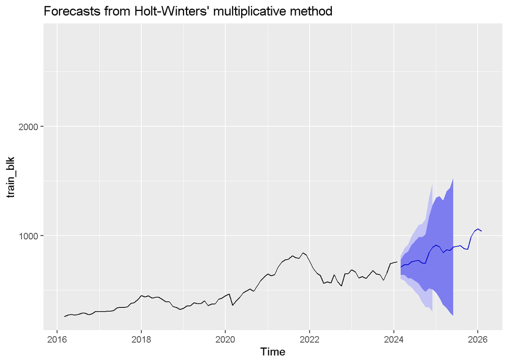

```r
autoplot(pred_mult_blk) +
  ylim(min(train_blk), max(pred_mult_blk$upper))
```

```r
#Overview table with MAPE as the comparison metric
comp_table = data.frame( Method = c("SES","HOLT","ADD_HW","MULT_HW"),
                         MAPE = c(mape_ses_blk,mape_holt_blk,mape_add_blk,mape_mult_blk))
comp_table
```

```
##    Method       MAPE
## 1     SES 0.19339311
## 2    HOLT 0.13988657
## 3  ADD_HW 0.12790390
## 4 MULT_HW 0.09218514
```

```r
attach (comp_table)

print("The best forecasting method for our data is: ")
```

```
## [1] "The best forecasting method for our data is: "
```

```r
c("SES","HOLT","ADD_HW","MULT_HW","MA3","MA6","MA12")[which.min(c(mape_ses_blk,mape_holt_blk,mape_add_blk,mape_mult_blk,mape_ma3_blk, mape_ma6_blk, mape_ma12_blk))]
```

```
## [1] "MULT_HW"
```

- Results & Interpretation:
  - By comparing the Mean Absolute Percentage Error (MAPE) across the four models, the Multiplicative Holt-Winters (MULT_HW) model minimizes the loss function. This suggests that while visual inspection did not reveal obvious seasonality, the algorithmic breakdown detects subtle seasonal variations that grow proportionately with the overall level of the stock price. We reject $H_0$ in favor of models that account for trend and multiplicative seasonality.

## Step 11: Performing Linear Regression

```r
# Define
n = length(blk_ts)
train_end = n - h
test_start = train_end + 1

tt = 1:length(train_blk)
tt_test = (length(train_blk)+1):n

fit_lm = lm(train_blk ~ tt)
summary(fit_lm)
```

```
##
## Call:
## lm(formula = train_blk ~ tt)
##
## Residuals:
##      Min       1Q   Median       3Q      Max
## -138.892  -67.007   -8.816   28.661  236.326
##
## Coefficients:
##             Estimate Std. Error t value Pr(>|t|)
## (Intercept) 249.4899    17.5750   14.20   <2e-16 ***
## tt            5.1720     0.3146   16.44   <2e-16 ***
## ---
## Signif. codes:  0 '***' 0.001 '**' 0.01 '*' 0.05 '.' 0.1 ' ' 1
##
## Residual standard error: 85.43 on 94 degrees of freedom
## Multiple R-squared:  0.7419, Adjusted R-squared:  0.7392
## F-statistic: 270.2 on 1 and 94 DF,  p-value: < 2.2e-16
```

```r
# Predict on test data
pred_linear = predict(fit_lm, newdata = data.frame(tt = tt_test))
pred_linear
```

```
##        1        2        3        4        5        6        7        8
## 751.1770 756.3490 761.5211 766.6931 771.8651 777.0372 782.2092 787.3812
##        9       10       11       12       13       14       15       16
## 792.5533 797.7253 802.8973 808.0694 813.2414 818.4134 823.5854 828.7575
##       17       18       19       20       21       22       23       24
## 833.9295 839.1015 844.2736 849.4456 854.6176 859.7897 864.9617 870.1337
```

```r
mape_linear = mape(test_blk, pred_linear)
mape_linear
```

```
## [1] 0.1435672
```

```r
print("The best forecasting method for our data is: ")
```

```
## [1] "The best forecasting method for our data is: "
```

```r
c("SES","HOLT","ADD_HW","MULT_HW","Linear Trend")[which.min(c(mape_ses_blk,mape_holt_blk,mape_add_blk,mape_mult_blk, mape_linear))]
```

```
## [1] "MULT_HW"
```

- After applying Linear Regression, the comparison table confirms that so far, Mult_HW is still the best model to predict our data. Next, we will fit the best ARIMA model.

## Step 12: Creating ARIMA model

```r
# Stationarity check
ndiffs(blk_ts)   # how many standard differences needed -> 1
```

```
## [1] 1
```

```r
nsdiffs(blk_ts)  # how many seasonal differences needed -> no seasonal differences needed
```

```
## [1] 0
```

```r
summary(ur.kpss(blk_ts))
```

```
##
## #######################
## # KPSS Unit Root Test #
## #######################
##
## Test is of type: mu with 4 lags.
##
## Value of test-statistic is: 2.1444
##
## Critical value for a significance level of:
##                 10pct  5pct 2.5pct  1pct
## critical values 0.347 0.463  0.574 0.739
```

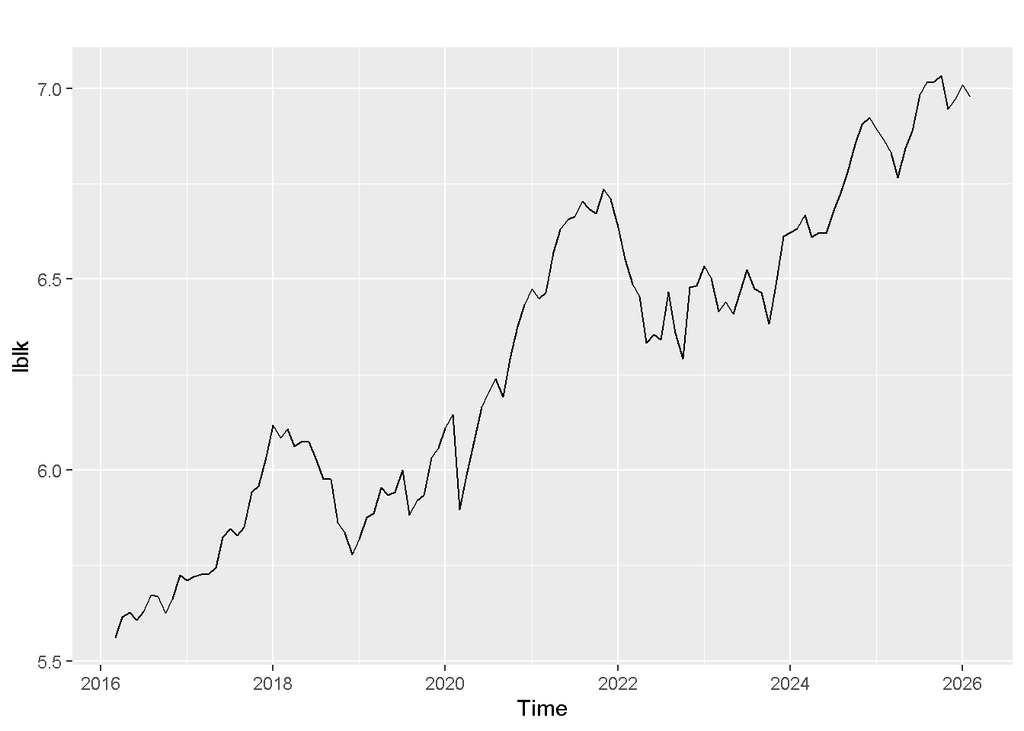

```r
# Transformation and differentiating
lblk = log(blk_ts)  # log transformation to stabilize variance
autoplot(lblk)
```

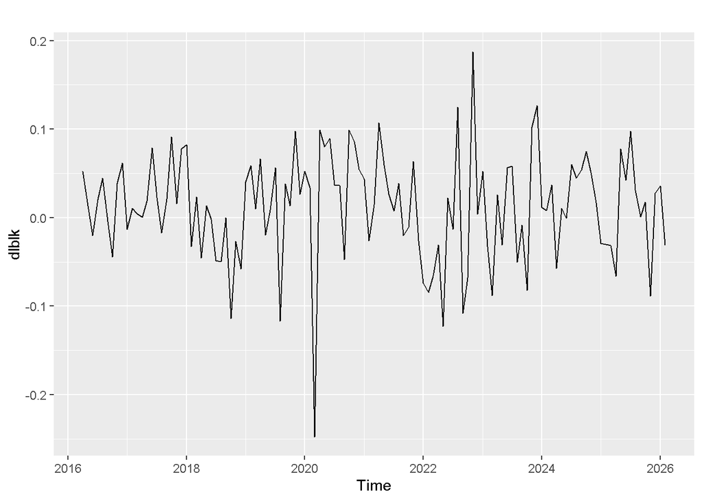

```r
dlblk = diff(lblk)
autoplot(dlblk)
```

```r
summary(ur.kpss(dlblk))   # Confirm stationarity
```

```
##
## #######################
## # KPSS Unit Root Test #
## #######################
##
## Test is of type: mu with 4 lags.
##
## Value of test-statistic is: 0.0488
##
## Critical value for a significance level of:
##                 10pct  5pct 2.5pct  1pct
## critical values 0.347 0.463  0.574 0.739
```

- Post-Transformation Diagnostics:
  - After applying a logarithmic transformation (to stabilize variance) and a first-order difference (to eliminate the trend), the new KPSS test statistic is $0.0488$. Because this is less than the $5\%$ critical value ($0.463$), we fail to reject $H_0$. The transformed series (dlblk) is now strictly stationary and suitable for ARIMA modeling.

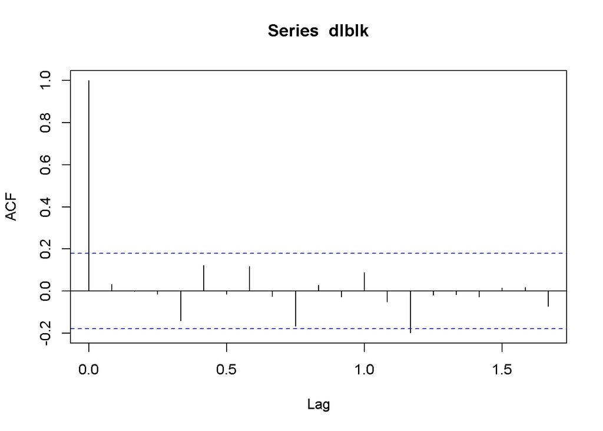

```r
# ACF and PACF
acf(dlblk)
```

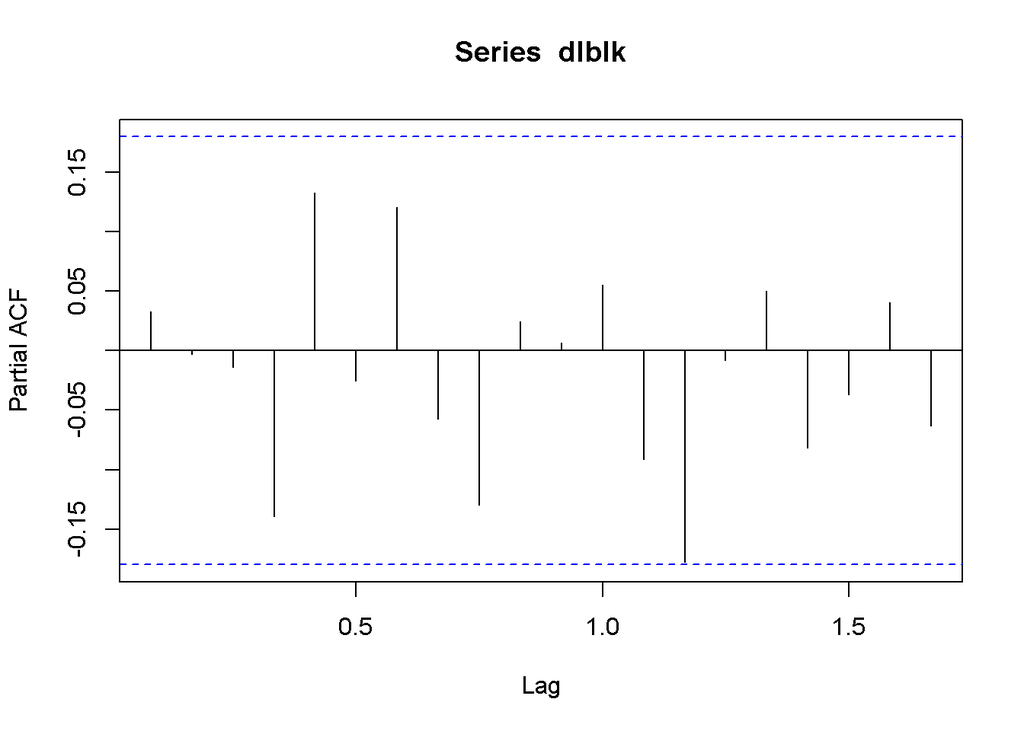

```r
pacf(dlblk)
```

## Step 13: Fit best ARIMA Model

```r
fit = auto.arima(train_blk)
summary(fit)
```

```
## Series: train_blk
## ARIMA(0,1,0)(1,0,0)[12]
##
## Coefficients:
##         sar1
##       0.2022
## s.e.  0.1040
##
## sigma^2 = 1157:  log likelihood = -469.61
## AIC=943.22   AICc=943.35   BIC=948.32
##
## Training set error measures:
##                    ME     RMSE      MAE     MPE     MAPE      MASE       ACF1
## Training set 4.328548 33.66409 25.27657 0.75183 4.952515 0.2207854 0.08633222
```

```r
coeftest(fit)
```

```
##
## z test of coefficients:
##
##      Estimate Std. Error z value Pr(>|z|)
## sar1  0.20224    0.10403  1.9442  0.05188 .
## ---
## Signif. codes:  0 '***' 0.001 '**' 0.01 '*' 0.05 '.' 0.1 ' ' 1
```

## Step 14:Forecast and Evaluate

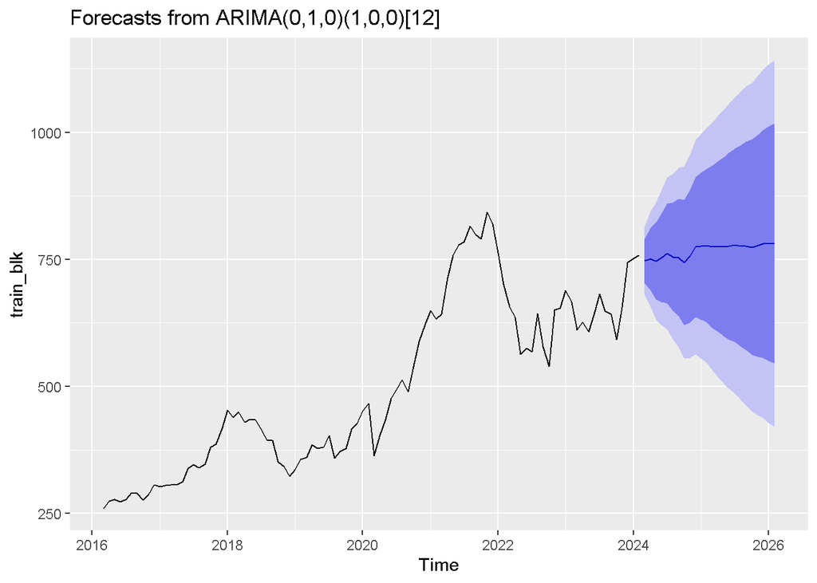

```r
pred = forecast(fit, h = h)
autoplot(pred)
```

```r
mape_arima = mape(as.numeric(test_blk), as.numeric(pred$mean))
mape_arima
```

```
## [1] 0.1830091
```

- Error Metric Interpretations: MAPE ($0.183$): On average, the ARIMA model’s forecasts deviate from the actual BlackRock stock prices by $18.3\%$.

## Step 15: Final Model Comparison

```r
comp_table_final = data.frame(
  Method = c("MA3","MA6","MA12","SES","HOLT","ADD_HW","MULT_HW","ARIMA","Linear"),
  MAPE   = c(mape_ma3_blk, mape_ma6_blk, mape_ma12_blk,
             mape_ses_blk, mape_holt_blk, mape_add_blk,
             mape_mult_blk, mape_arima, mape_linear))

comp_table_final
```

```
##    Method       MAPE
## 1     MA3 0.19856936
## 2     MA6 0.26245370
## 3    MA12 0.29162739
## 4     SES 0.19339311
## 5    HOLT 0.13988657
## 6  ADD_HW 0.12790390
## 7 MULT_HW 0.09218514
## 8   ARIMA 0.18300906
## 9  Linear 0.14356721
```

```r
print("The best forecasting method is:")
```

```
## [1] "The best forecasting method is:"
```

```r
comp_table_final$Method[which.min(comp_table_final$MAPE)]
```

```
## [1] "MULT_HW"
```

- Final Model Selection and Inference:
  - Conclusion: After evaluating deterministic (Moving Average, Linear Trend), smoothing (Exponential), and probabilistic (ARIMA) models, the Multiplicative Holt-Winters (MULT_HW) model achieves the lowest MAPE on the out-of-sample test data.
  - Why MULT_HW wins: It explicitly models both the long-term upward trend and subtle multiplicative seasonality — where price volatility grows proportionally with the stock’s level.
  - Why ARIMA underperforms: The identified model ARIMA(0,1,0) behaves essentially as a random walk with a borderline insignificant seasonal parameter (p = 0.052), resulting in poor generalization from training (MAPE ~5%) to test data (MAPE ~18%).
  - Moving Average: Produces flat forecasts by repeating the last known average — useful as a baseline benchmark but structurally unable to follow BLK’s upward trend.
  - Linear Regression: Confirms a statistically significant trend of ~5.17 USD/month (R² = 0.74) but is too rigid to capture non-linear price accelerations.
  - Limitation: Stock prices are inherently difficult to forecast due to external shocks (e.g. COVID-19 crash visible in the 2020 data, interest rate decisions)
  - Final Market Inference: The superior performance of the MULT_HW model indicates that BlackRock’s stock price trajectory is best defined by an ongoing structural upward trend compounded by proportional cyclical fluctuations. Based on our optimal model’s predictions, the forecasted market price maintains a bullish trajectory, though investors should account for the expanding prediction intervals which represent increasing market uncertainty over a longer time horizon.